# HW-5 (answer key: Titanic-KNN Classification)

[Titanic competition from Kaggle](https://www.kaggle.com/c/titanic).

Instructor: [Pedram Jahangiry](https://github.com/PJalgotrader)

```python
import numpy as np
import pandas as pd
import matplotlib.pyplot as plt
import seaborn as sns
from sklearn.neighbors import KNeighborsClassifier
sns.set()  #if you want to use seaborn themes with matplotlib functions
```

### Data Preprocessing

```python
df = pd.read_csv('titanic_train_clean.csv')
df_test = pd.read_csv('titanic_test_clean.csv')
```

```python
df.head()
```

|  | PassengerId | Survived | Age | SibSp | Parch | Fare | Cabin_known | Pclass_2 | Pclass_3 | Sex_male | Embarked_Q | Embarked_S |
| --- | --- | --- | --- | --- | --- | --- | --- | --- | --- | --- | --- | --- |
| 0 | 1 | 0 | 22.0 | 1 | 0 | 7.2500 | 0 | 0 | 1 | 1 | 0 | 1 |
| 1 | 2 | 1 | 38.0 | 1 | 0 | 71.2833 | 1 | 0 | 0 | 0 | 0 | 0 |
| 2 | 3 | 1 | 26.0 | 0 | 0 | 7.9250 | 0 | 0 | 1 | 0 | 0 | 1 |
| 3 | 4 | 1 | 35.0 | 1 | 0 | 53.1000 | 1 | 0 | 0 | 0 | 0 | 1 |
| 4 | 5 | 0 | 35.0 | 0 | 0 | 8.0500 | 0 | 0 | 1 | 1 | 0 | 1 |

```python
df.info()
```

```
<class 'pandas.core.frame.DataFrame'>
RangeIndex: 889 entries, 0 to 888
Data columns (total 12 columns):
PassengerId    889 non-null int64
Survived       889 non-null int64
Age            889 non-null float64
SibSp          889 non-null int64
Parch          889 non-null int64
Fare           889 non-null float64
Cabin_known    889 non-null int64
Pclass_2       889 non-null int64
Pclass_3       889 non-null int64
Sex_male       889 non-null int64
Embarked_Q     889 non-null int64
Embarked_S     889 non-null int64
dtypes: float64(2), int64(10)
memory usage: 83.4 KB
```

# Question 1: KNN (Classification)

1- Use KNN model from Sklearn package and report the estimated error_rate_test of your model. Note that because the original target variables in the test set are unobservable, you need to estimate this accuracy_test by applying cross validation to the train set (try K=5 and K=10).

2- Find the optimal number of k (neighbors)

```python
# Defining the target and feature space for both train and test set. Note that the target for the test set is unknown.

X_train= df.drop(['PassengerId','Survived'], axis=1)
y_train= df['Survived']

X_test= df_test.drop('PassengerId',axis=1)
```

```python
X_train.head()
```

|  | Age | SibSp | Parch | Fare | Cabin_known | Pclass_2 | Pclass_3 | Sex_male | Embarked_Q | Embarked_S |
| --- | --- | --- | --- | --- | --- | --- | --- | --- | --- | --- |
| 0 | 22.0 | 1 | 0 | 7.2500 | 0 | 0 | 1 | 1 | 0 | 1 |
| 1 | 38.0 | 1 | 0 | 71.2833 | 1 | 0 | 0 | 0 | 0 | 0 |
| 2 | 26.0 | 0 | 0 | 7.9250 | 0 | 0 | 1 | 0 | 0 | 1 |
| 3 | 35.0 | 1 | 0 | 53.1000 | 1 | 0 | 0 | 0 | 0 | 1 |
| 4 | 35.0 | 0 | 0 | 8.0500 | 0 | 0 | 1 | 1 | 0 | 1 |

```python
y_train.head()
```

```
0    0
1    1
2    1
3    1
4    0
Name: Survived, dtype: int64
```

## Scaling the features:

The following step is very important for **Classification** specially for KNN. Because any variable on the larger scale, has a larger effect on the distance between observations.

1. Rescale the entire data set using StandardScaler
2. Rescale the individual features.

For KNN it is highly recommended that we use the first method and this is what I will do after splitting the data into train and test.

```python
from sklearn.preprocessing import StandardScaler
sc = StandardScaler()
X_train_sc = sc.fit_transform(X_train)
X_test_sc = sc.transform(X_test)
```

```python
X_train_sc[0:2,:]
```

```
array([[-0.53167023,  0.43135024, -0.47432585, -0.50023975, -0.5422472 ,
        -0.51087465,  0.90032807,  0.73534203, -0.30794088,  0.61679395],
       [ 0.68023223,  0.43135024, -0.47432585,  0.78894661,  1.84417735,
        -0.51087465, -1.11070624, -1.35991138, -0.30794088, -1.62128697]])
```

```python
X_train.describe().T
```

|  | count | mean | std | min | 25% | 50% | 75% | max |
| --- | --- | --- | --- | --- | --- | --- | --- | --- |
| Age | 889.0 | 29.019314 | 13.209814 | 0.42 | 22.0000 | 26.0000 | 36.5 | 80.0000 |
| SibSp | 889.0 | 0.524184 | 1.103705 | 0.00 | 0.0000 | 0.0000 | 1.0 | 8.0000 |
| Parch | 889.0 | 0.382452 | 0.806761 | 0.00 | 0.0000 | 0.0000 | 0.0 | 6.0000 |
| Fare | 889.0 | 32.096681 | 49.697504 | 0.00 | 7.8958 | 14.4542 | 31.0 | 512.3292 |
| Cabin_known | 889.0 | 0.227222 | 0.419273 | 0.00 | 0.0000 | 0.0000 | 0.0 | 1.0000 |
| Pclass_2 | 889.0 | 0.206974 | 0.405365 | 0.00 | 0.0000 | 0.0000 | 0.0 | 1.0000 |
| Pclass_3 | 889.0 | 0.552306 | 0.497536 | 0.00 | 0.0000 | 1.0000 | 1.0 | 1.0000 |
| Sex_male | 889.0 | 0.649044 | 0.477538 | 0.00 | 0.0000 | 1.0000 | 1.0 | 1.0000 |
| Embarked_Q | 889.0 | 0.086614 | 0.281427 | 0.00 | 0.0000 | 0.0000 | 0.0 | 1.0000 |
| Embarked_S | 889.0 | 0.724409 | 0.447063 | 0.00 | 0.0000 | 1.0000 | 1.0 | 1.0000 |

## Train the model

```python
KNN_classification = KNeighborsClassifier(n_neighbors=5)
KNN_classification.fit(X_train_sc,y_train)
```

```
KNeighborsClassifier(algorithm='auto', leaf_size=30, metric='minkowski',
                     metric_params=None, n_jobs=None, n_neighbors=5, p=2,
                     weights='uniform')
```

```python
y_hat = KNN_classification.predict(X_test_sc)
```

## Evaluation

We cannot evaluate the model directly because the test sample is unsupervised. We don't have actual y in the test set. However, we can use the Cross validation with the train set to estimate the accuracy of the test set.

```python
# defining our own confusion matrix function
from sklearn.metrics import confusion_matrix
def my_confusion_matrix(y, y_hat):
    cm = confusion_matrix(y, y_hat)
    TN, FP, FN, TP = cm[0,0], cm[0,1], cm[1,0], cm[1,1]
    accuracy = round((TP+TN) / (TP+ FP+ FN+ TN) ,2)
    precision = round( TP / (TP+FP),2)
    recall = round( TP / (TP+FN),2)
    cm_labled = pd.DataFrame(cm, index=['Actual : 0 ','Actual : 1'], columns=['Predict : 0','Predict :1 '])
    print('\n')
    print('Accuracy = {}'.format(accuracy))
    print('Precision = {}'.format(precision))
    print('Recall = {}'.format(recall))
    print("-----------------------------------------")
    return cm_labled
```

We can report the confusion matrix for the training set! However, this is not the question of interest.

```python
my_confusion_matrix(y_train,KNN_classification.predict(X_train_sc) )
```

```
Accuracy = 0.86
Precision = 0.83
Recall = 0.8
-----------------------------------------
```

|  | Predict : 0 | Predict :1 |
| --- | --- | --- |
| Actual : 0 | 495 | 54 |
| Actual : 1 | 68 | 272 |

### Cross validation

Now let's try to get an estimate for the accuracy of our model in the test set by applying cross validation technique to the training set.

```python
from sklearn.model_selection import cross_val_score
```

```python
Accuracy_CV=[]
K = (5,10)
for i in K:
    accuracy = cross_val_score(estimator = KNN_classification, X = X_train_sc, y = y_train, cv = i , scoring="accuracy" )
    Accuracy_CV.append(round(accuracy.mean(),3))

Accuracy_CV_df = pd.DataFrame(K, columns=['K'])
Accuracy_CV_df['Accuracy_CV']= Accuracy_CV

Accuracy_CV_df
```

|  | K | Accuracy_CV |
| --- | --- | --- |
| 0 | 5 | 0.801 |
| 1 | 10 | 0.794 |

So the estimated version of **accuracy_test** of the model is **0.801** using **5-fold** and **0.794** using **10-fold** cross validation. Note that these numbers are smaller than the **accuracy_train** which is **0.86**.

Question 1 is asking about the **error_rate_CV_5 fold**. So let's report that number:

```python
MAE_i =  -1*cross_val_score(estimator = KNeighborsClassifier(n_neighbors=5), X = X_train_sc, y = y_train, cv = 5 , scoring="neg_mean_absolute_error" )
CV_error_rate= np.round((np.mean(MAE_i)),3)
CV_error_rate
```

```
0.199
```

Not surprisingly, the error rate = 1 - accuracy

## Choosing K

We need to use error_rate with cross validation because the target test is not observable.

```python
CV_error_rate=[]
k=50

for i in range(1,k):
    KNN_i = KNeighborsClassifier(n_neighbors=i)
    KNN_i.fit(X_train, y_train)
    MAE_i =  -1*cross_val_score(estimator = KNN_i, X = X_train_sc, y = y_train, cv = 5 , scoring="neg_mean_absolute_error" )
    CV_error_rate.append(np.mean(MAE_i))

optimal_k = pd.DataFrame({'CV_error_rates': CV_error_rate}, index=range(1,k))
```

```python
optimal_k.head(10)
```

|  | CV_error_rates |
| --- | --- |
| 1 | 0.254206 |
| 2 | 0.220447 |
| 3 | 0.197943 |
| 4 | 0.205834 |
| 5 | 0.199086 |
| 6 | 0.197988 |
| 7 | 0.194611 |
| 8 | 0.203580 |
| 9 | 0.197950 |
| 10 | 0.199086 |

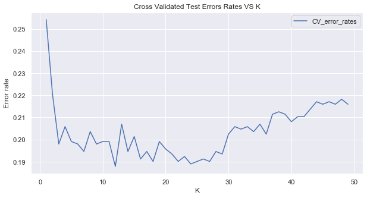

```python
plt.figure(figsize=(10,5))
sns.lineplot(data=optimal_k)
plt.title('Cross Validated Test Errors Rates VS K')
plt.xlabel('K')
plt.ylabel('Error rate')
plt.show()
```

```python
np.argmin(optimal_k['CV_error_rates'], axis=0)
```

```
12
```

**So the optimal K=12**. Now let's rerun the model with k=12 and save the predictions for Kaggle submission

```python
y_hat = KNeighborsClassifier(n_neighbors=12).fit(X_train_sc,y_train).predict(X_test_sc)
```

### Question 2: Kaggle csv submission

```python
predictions = pd.DataFrame(y_hat, columns=["Survived"])
predictions.head()
```

|  | Survived |
| --- | --- |
| 0 | 0 |
| 1 | 0 |
| 2 | 0 |
| 3 | 0 |
| 4 | 1 |

```python
Kaggle_submission= pd.concat([df_test['PassengerId'],predictions], axis=1)
```

```python
Kaggle_submission.head()
```

|  | PassengerId | Survived |
| --- | --- | --- |
| 0 | 892 | 0 |
| 1 | 893 | 0 |
| 2 | 894 | 0 |
| 3 | 895 | 0 |
| 4 | 896 | 1 |

```python
Kaggle_submission.to_csv("Titanic_KNN.csv", index=False)
```

### My score in Kaggle competition:

- Logistic regression: Score 0.77033 , rank 10,410
- KNN Classification : Score **0.77511** , rank **9,767**

So far, the KNN with K=12 outbid the logistic regression model.